# R Notebook

# Contexto dos dados

Os dados são sobre queimadas link: https://archive.ics.uci.edu/ml/datasets/Forest+Fires.

1. X - x-axis spatial coordinate within the Montesinho park map: 1 to 9
2. Y - y-axis spatial coordinate within the Montesinho park map: 2 to 9
3. month - month of the year: “jan” to “dec”
4. day - day of the week: “mon” to “sun”
5. FFMC - FFMC index from the FWI system: 18.7 to 96.20
6. DMC - DMC index from the FWI system: 1.1 to 291.3
7. DC - DC index from the FWI system: 7.9 to 860.6
8. ISI - ISI index from the FWI system: 0.0 to 56.10
9. temp - temperature in Celsius degrees: 2.2 to 33.30
10. RH - relative humidity in %: 15.0 to 100
11. wind - wind speed in km/h: 0.40 to 9.40
12. rain - outside rain in mm/m2 : 0.0 to 6.4
13. area - the burned area of the forest (in ha): 0.00 to 1090.84 (this output variable is very skewed towards 0.0, thus it may make sense to model with the logarithm transform).

# Análise descritiva

O material [Applied Multivariate Analysis, Darren Homrighausen, PhD](https://darrenho.github.io/AMA/regression4example.pdf) utiliza um mecanismo para visualizar a média das áreas queimadas, conforme a localização X e Y no conjunto de dados.

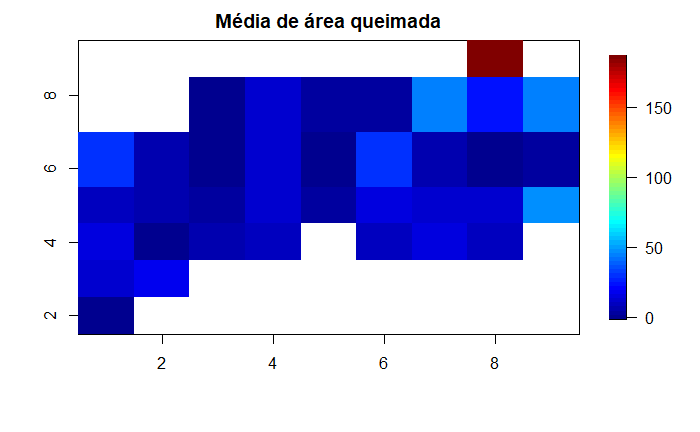

O interesse é modelar áreas que foram queimadas. Analisando o conjunto de dados, notamos que 47.78% é de área não queimada.

Sendo assim, iremos filtrar nosso conjunto de dados selecionando apenas os registros que a coluna **area > 0**.

Outra alternativa seria aplicar alguma transformação na variável resposta, como um log por exemplo. **ainda n coloquei este cenário (log de area) no código**

| X | Y | month | day | FFMC | DMC | DC | ISI | temp | RH | wind | rain | area | isBurned |
| --- | --- | --- | --- | --- | --- | --- | --- | --- | --- | --- | --- | --- | --- |
| 9 | 9 | jul | tue | 85.8 | 48.3 | 313.4 | 3.9 | 18.0 | 42 | 2.7 | 0.0 | 0.36 | 1 |
| 1 | 4 | sep | tue | 91.0 | 129.5 | 692.6 | 7.0 | 21.7 | 38 | 2.2 | 0.0 | 0.43 | 1 |
| 2 | 5 | sep | mon | 90.9 | 126.5 | 686.5 | 7.0 | 21.9 | 39 | 1.8 | 0.0 | 0.47 | 1 |
| 1 | 2 | aug | wed | 95.5 | 99.9 | 513.3 | 13.2 | 23.3 | 31 | 4.5 | 0.0 | 0.55 | 1 |
| 8 | 6 | aug | fri | 90.1 | 108.0 | 529.8 | 12.5 | 21.2 | 51 | 8.9 | 0.0 | 0.61 | 1 |
| 1 | 2 | jul | sat | 90.0 | 51.3 | 296.3 | 8.7 | 16.6 | 53 | 5.4 | 0.0 | 0.71 | 1 |
| 2 | 5 | aug | wed | 95.5 | 99.9 | 513.3 | 13.2 | 23.8 | 32 | 5.4 | 0.0 | 0.77 | 1 |
| 6 | 5 | aug | thu | 95.2 | 131.7 | 578.8 | 10.4 | 27.4 | 22 | 4.0 | 0.0 | 0.90 | 1 |
| 5 | 4 | mar | mon | 90.1 | 39.7 | 86.6 | 6.2 | 13.2 | 40 | 5.4 | 0.0 | 0.95 | 1 |
| 8 | 3 | sep | tue | 84.4 | 73.4 | 671.9 | 3.2 | 24.2 | 28 | 3.6 | 0.0 | 0.96 | 1 |

[output cut: 260 more lines]

# Forward Regression

```r
minimal.model = lm(area ~ 1, data = tempdat)
forward.model = MASS::stepAIC(minimal.model,
                               scope = list(upper = ~ X + Y + month + day + FFMC + DMC + DC + ISI + temp + RH + wind + rain,  lower = ~1),
                              direction="forward",trace = TRUE)

tidy(forward.model)
print(forward.model)
```

[output not shown]

# Backward Regression

```r
full.model = lm(area ~ X + Y + month + day + FFMC + DMC + DC + ISI + temp + RH + wind + rain, data = tempdat)
backward.model = MASS::stepAIC(full.model,
                                scope = list(upper = ~ X + Y + month + day + FFMC + DMC + DC + ISI + temp + RH + wind + rain,  lower = ~1),
                               direction="backward",trace = TRUE)


backward.model
```

[output not shown]

# Stepwise Regression

```r
initial.model = lm(area ~ 1, data = tempdat)
stepwise.model = MASS::stepAIC(initial.model,
                                scope = list(upper = ~ X + Y + month + day + FFMC + DMC + DC + ISI + temp + RH + wind + rain,  lower = ~1),
                               direction="both",trace = TRUE)
# tidy(stepwise.model)
stepwise.model
```

[output not shown]